# MAGLEV Simulação Iterativa - ControlXperience

## Sobre o ControlXperience

ControlXperience é um laboratório virtual de controle projetado para fornecer simulações interativas de sistemas de controle. Ele utiliza a linguagem de programação Python e a biblioteca VPython para criar animações envolventes e gráficos detalhados das simulações. Seu principal objetivo é oferecer uma experiência completa e imersiva no estudo e prática de controle de sistemas.Essas simulações foram criadas com o principal objetivo de aplicá-las aos estudantes de graduação em engenharia da UFPA campus Tucuruí.

## Sobre o módulo MAGLEV

O módulo “MAGLEV” faz parte de um conjunto de simulações desenvolvidas para integrar o controlXperience de controle com finalidade didática. Ao utilizar o módulo “MAGLEV”, os usuários têm a oportunidade de aplicar os conhecimentos teóricos aprendidos em sala de aula, realizando simulações interativas que ilustram os princípios do controle de sistemas. Através da animação e visualização dos resultados, os estudantes podem adquirir uma compreensão prática dos conceitos abordados, aprimorando assim seu aprendizado na área de controle.

## Como funciona o MAGLEV?

O princípio de funcionamento do MAGLEV baseia-se na aplicação de campos magnéticos opostos entre o objeto a ser levitado e a base de suporte. Esses campos magnéticos criam uma atração magnética, contrabalançando a força da gravidade e permitindo que o objeto permaneça suspenso no ar, conforme a Figura 1.

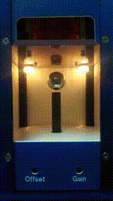

Figura 1 - Exemplo de levitação magnética

Existem diferentes configurações de levitadores magnéticos, mas a mais comum é o levitador eletromagnético. Nesse sistema, a base de suporte é equipada com bobinas eletromagnéticas que geram campos magnéticos variáveis. Por sua vez, o objeto a ser levitado possui ímãs permanentes que interagem com os campos magnéticos da base.

Ao variar a corrente elétrica nas bobinas eletromagnéticas da base, é possível controlar a intensidade e a direção dos campos magnéticos gerados. Isso permite ajustar a força magnética e, consequentemente, controlar a altura de levitação do objeto, de acordo com a Figura 2.

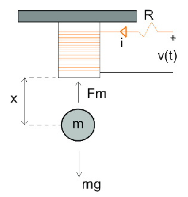

Figura 2 - Esquema do levitador magnético

## O MAGLEV em malha aberta

O MAGLEV é um sistema que apresenta características de instabilidade. Essa instabilidade é refletida na localização dos polos do sistema no semiplano direito do plano complexo.

Essa propriedade de instabilidade do MAGLEV é um aspecto fundamental a ser considerado ao projetar e controlar o sistema. Por estar no semiplano direito, os polos indicam que o sistema possui respostas transitórias não amortecidas, o que pode resultar em comportamentos indesejados, como oscilações ou divergência do sistema. Na Equação 1 é apresentado a função de transerência do sistema.

$$G(s) = \dfrac{32,7}{s^2-5644}\tag{1}$$

Para tornar o levitador magnético controlável e estável, é necessário empregar técnicas de controle apropriadas. O uso de um sistema de controle adequado permite compensar a instabilidade inerente ao MAGLEV e garantir um comportamento estável e controlado. Isso envolve a implementação de estratégias de controle que levam em conta as características do sistema e buscam estabilizá-lo por meio de realimentação e ajustes precisos.

Dessa forma, o controle é essencial para superar a instabilidade natural do MAGLEV e obter um desempenho confiável e controlado. Ao aplicar técnicas de controle adequadas, é possível estabilizar o sistema, mitigar os efeitos da instabilidade e garantir o correto funcionamento do levitador magnético em diferentes condições e aplicações. Um LGR do sistema é apresentado na Figura 3.

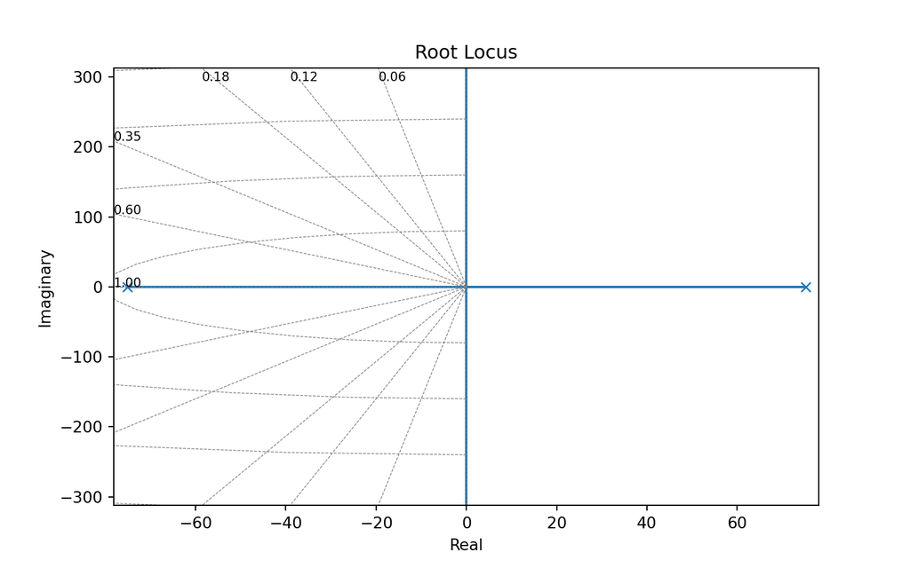

Figura 3 - LGR do MAGLEV

## A animação e simulação do MAGLEV

A animação e simulação do MAGLEV foi desenvolvida utilizando a biblioteca Vpython do Python. O sistema foi dividido em módulos de programas, conforme é ilustrado na Figura 4.

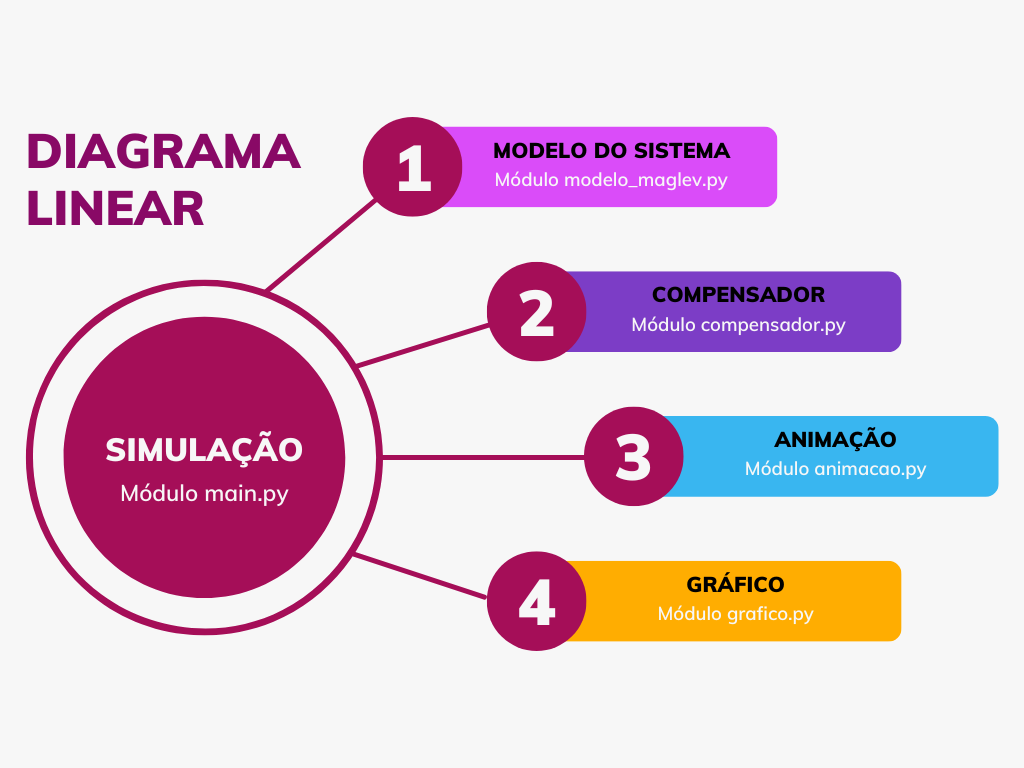

Figura 4 - Diagrama linear dos módulos utlizados

O sistema final é apresentado na Figura 5.

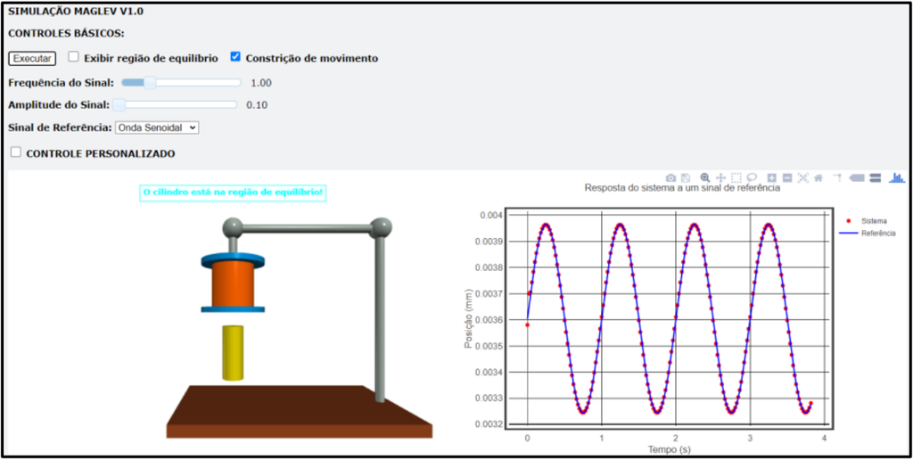

Figura 5 - Simulação do MAGLEV

## Como rodar o código o sistema localmente

Para disponibilizar esse sistema para os usuários foi desenvolvido a biblioteca `labvirtual 0.3.19` na plataforma PyPi que contém os módulos citados na seção anterior.

O primeiro passo é instalar a biblioteca na sua IDE.

Instalação com o pip:

> pip install labvirtual

Instalação com o conda:

> conda install labvirtual

Instalação com o poetry:

> poetry add labvirtual

Após a instalação da biblioteca, você pode criar um arquivo chamado `main.py` e colar nele o código abaixo.

```
# -----------------------------------------------------
# Universidade Federal do Pará
# Campus Universitário de Tucuruí
# Faculdade de Engenharia Elétrica
# -----------------------------------------------------
#
# Laboratório Virtual Sistemas Dinâmicos e Controle
# Simulador: Maglev
# Autor: Yuri Cota
# Orientadores: Prof. Dr: Raphael Teixeira,
#               Prof. Dr: Rafael Bayma
#
# Data: 2023
#  ----------------------------------------------------
#
# Bibliotecas
import time

import numpy as np
from scipy.integrate import solve_ivp
import vpython as vp

# Importando o Modelo Matemático do Maglev
from labvirtual.simulador_maglev import Maglev

# Importando o Compensador
from labvirtual.simulador_maglev import Compensador

# Importando Simulador e Gráfico
from labvirtual.simulador_maglev import Simulacao
from labvirtual.simulador_maglev import Grafico


def run_maglev():
    legenda_1 = "<b>O cilindro está na posição inicial!</b>"
    legenda_2 = "<b>O cilindro está na região de equilíbrio!</b>"
    legenda_3 = "<b>O cilindro está fora da região de equilíbrio!</b>"
    legenda_4 = "<b>Aguarde o cilindro retonar a posição incial!</b>"
    # Criação dos objetos da planta e controlador para simular
    mag = Maglev(m=29e-3, k=9.55e-6, mu=2.19e-3, I0=1)
    comp = Compensador(mag, [-3*mag.lamda]*3, [-8*mag.lamda]*2)

    # CONTROLE PERSONALIZADO ----------------------

    # Descomente o código abaixo e insira as matrizes do seu controlador

    # comp.K = []
    # comp.Ar = []
    # comp.Br = []

    # ---------------------------------------------

    # Criando um Objeto Simulacao
    sim = Simulacao(mag_x0=mag.x0)

    grafico = Grafico()

    # Definindo os sinais de referência para rastreamento
    def ref_seno(t):
        return (mag.x0*np.sin(2*vp.pi*t))

    def ref_quad(t):
        return (mag.x0)*(np.sin(2*vp.pi*t) >= 0)

    # Função para ajustar coordenadas do modelo às coordenadas do VPython
    def converte_posicao(y_maglev):
        return (sim.bobina_3.pos + vp.vec(0, -y_maglev, 0))*4

    # Função para implementar ruído gaussiano
    def ruido(amp):
        return amp*np.random.normal(loc=0, scale=amp)

    # LOOP -------------------------------------------------------------------
    # Criando o loop da simulação
    while True:
        vp.rate(sim.fps)
        # Verificação da posição do cilindro antes de executar o programa
        if sim.cil.pos == vp.vector(12e-2, -3.5e-2, 0):
            grafico.legenda_1.text = legenda_1
            grafico.legenda_1.color = vp.color.green
        elif sim.cil.pos == vp.vector(0, 0, 0):
            grafico.legenda_1.text = "<b>Cilindo grudado!</b>"
            grafico.legenda_1.color = vp.color.red
        elif sim.cil.pos.y <= 0 and sim.cil.pos.y >=\
                -0.08 and sim.cil.pos.x == 0:
            grafico.legenda_1.text = legenda_2
            grafico.legenda_1.color = vp.color.cyan
        else:
            grafico.legenda_1.text = legenda_3
            grafico.legenda_1.color = vp.color.purple

        # Acionando o botão executar
        if sim.executar:
            # O primeiro caso: se o cilindro está na posição inicial o
            # programa não vai sair da tela inicial.
            if sim.cil.pos == vp.vector(12e-2, -3.5e-2, 0):
                sim.cil.pos = vp.vector(12e-2, -3.5e-2, 0)
                grafico.yplot.delete()
                grafico.rplot.delete()
                sim.t = 0
                # time.sleep(2)
                sim.executar = not sim.executar
                sim.bt1_exe.text = "Executar"

            #  O segundo caso: o cilindro está grudado no eletroimã,
            # tem que aguardar o programa voltar pra tela inicial.
            elif sim.cil.pos == vp.vector(0, 0, 0):
                time.sleep(3)
                sim.executar = not sim.executar
                sim.bt1_exe.text = "Executar"
                sim.cil.pos = vp.vector(12e-2, -3.5e-2, 0)

            # O terceiro caso: o cilindro está na região
            # de equilíbrio, logo o programa irá rodar normalmente.
            elif sim.cil.pos.y <= 0 and sim.cil.pos.y >=\
                    -0.08 and sim.cil.pos.x == 0:

                # Atualiza o sinal de referência para enviar para o solver
                match sim.M.index:
                    case 0 | None:
                        def sinal(t):
                            return ref_seno(sim.sl.value*sim.t)*(sim.sl2.value)
                    case 1:
                        def sinal(t):  # noqa: F811
                            return ref_quad(sim.sl.value*sim.t)*(sim.sl2.value)

                # Chama o solver para atualizar os estados do maglev
                sol = solve_ivp(Maglev.estadosmf, t_span=[
                                sim.t, sim.t+sim.dt], y0=sim.y,
                                args=(sinal, mag, comp))

                # Recupera os resultados da simulação
                sim.y = sol.y[:, -1]+ruido(1e-6)

                # Atualiza os gráficos
                grafico.yplot.plot(sim.t, sim.y[0])
                grafico.rplot.plot(sim.t, sinal(sim.t)+mag.x0)
                # print(y[0])

                # Atualiza a posição do cilindro
                sim.cil.pos = converte_posicao(sim.y[0])

                # Atualiza o tempo
                sim.t += sim.dt
    # O quarto caso: o cilindro está fora da região de equilíbrio,
    # logo ele irá cair na mesa e retornar a posição inicial.
            else:
                while sim.cil.pos.y >= -3.5e-2:
                    vp.rate(sim.fps)
                    sim.cil.v = sim.cil.v+sim.g*sim.dt
                    sim.cil.pos = sim.cil.pos+sim.cil.v*sim.dt
                    sim.t = sim.t+sim.dt
                grafico.legenda_1.text = legenda_4
                grafico.legenda_1.color = vp.color.red
                time.sleep(4)
                sim.cil.pos = vp.vector(12e-2, -3.5e-2, 0)
                print(sim.t)


if __name__ == "__main__":
    run_maglev()
```

# Controle personalizado

Se o usuário quiser inserir o próprio controlador para o sistema, ele pode fornecer as matrizes do sistema aumentado (Ar e Br) e a dos ganhos (K). Para isso, é necessário descomentar o seguinte trecho no código fornecido a priori.

```
    # CONTROLE PERSONALIZADO ----------------------

    # Descomente o código abaixo e insira as matrizes do seu controlador

    # comp.K = []
    # comp.Ar = []
    # comp.Br = []

    # ---------------------------------------------
```

# Avaliação do módulo

Agradecemos pelo seu interesse em nosso módulo Maglev! Sua opinião é muito importante para nós. Gostaríamos de convidá-lo(a) a fazer uma avaliação do nosso módulo por meio de um breve questionário.

Para acessar o formulário de avaliação, por favor, siga o link abaixo:

[Formulário de Avaliação do Módulo Maglev](https://forms.gle/3KjypRvmMMfMoFKf8)

O questionário contém perguntas relacionadas à sua experiência com o módulo, como a facilidade de uso, a clareza das instruções e a qualidade das simulações. Sua avaliação nos ajudará a aprimorar o módulo e oferecer uma melhor experiência aos usuários.

Agradecemos antecipadamente pelo seu tempo e feedback. Sua opinião é valiosa para nós e nos ajuda a melhorar continuamente nossos recursos de ensino. Se você tiver alguma dúvida ou comentário adicional, sinta-se à vontade para compartilhá-los no formulário.

Mais uma vez, agradecemos por sua participação e dedicação em avaliar nosso módulo Maglev. Esperamos que você tenha tido uma experiência positiva e que nossos recursos tenham sido úteis para você.